# Demystifying Data

03 - Risk, Uncertainty and Knowledge

Mick Cooney mcooney@describedata.com

2022-09-22

# Knowledge

## Donald Rumsfeld

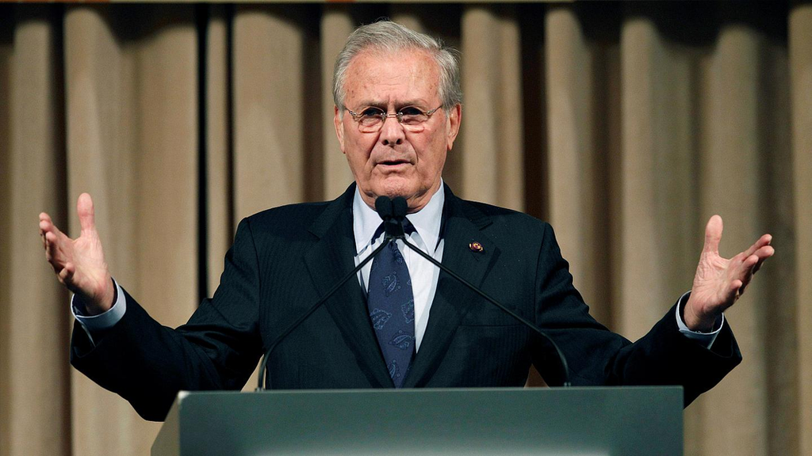

Reports that say that something hasn’t happened are always interesting to me, because as we know, there are known knowns; there are things we know we know.

We also know there are known unknowns; that is to say we know there are some things we do not know.

But there are also unknown unknowns - the ones we don’t know we don’t know.

And if one looks throughout the history of our country and other free countries, it is the latter category that tends to be the difficult ones.

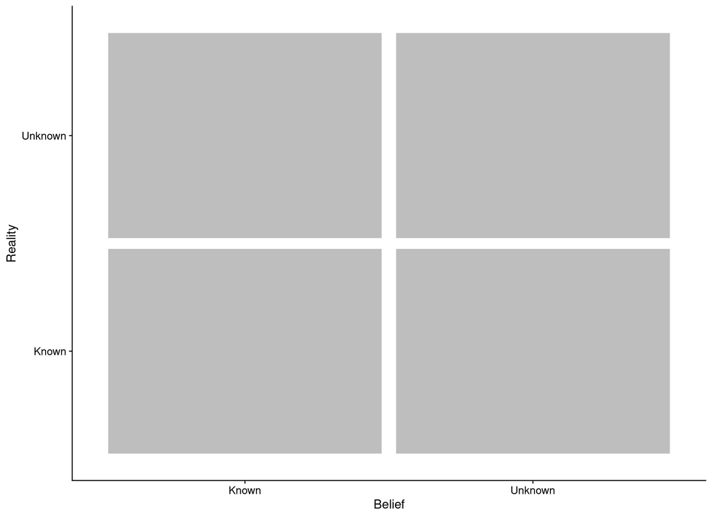

## Mark Twain

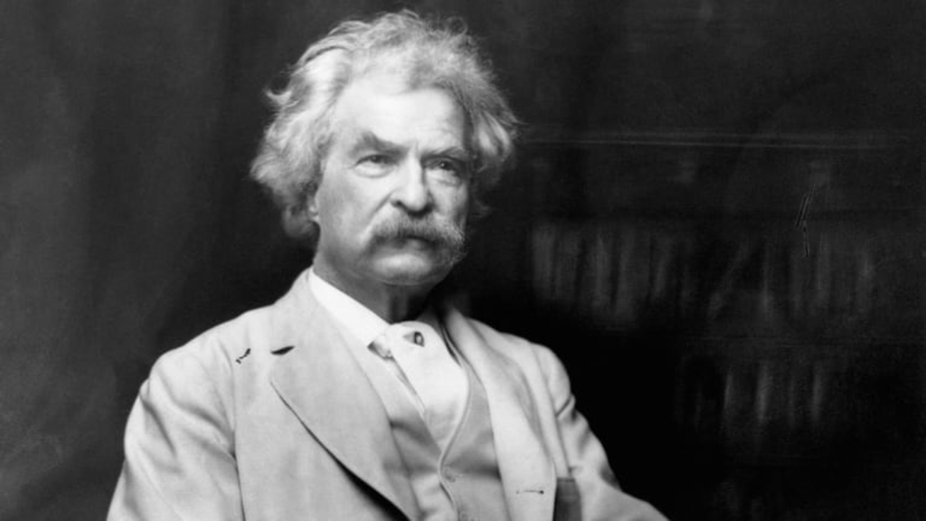

It ain’t what you don’t know that gets you into trouble…

… It’s what you know for sure that just ain’t so.

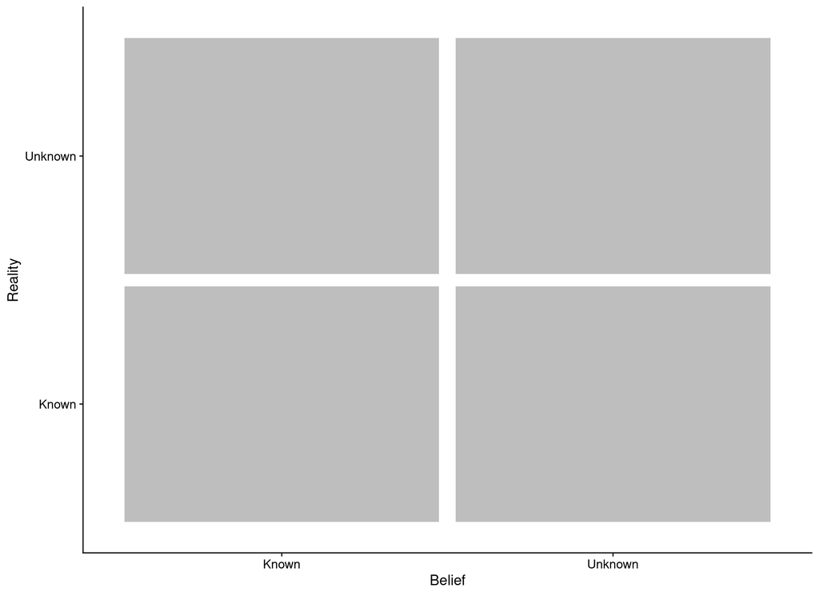

# Risk vs Uncertainty

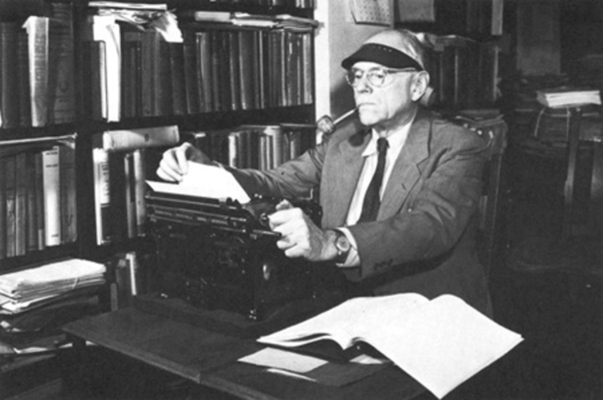

Frank Knight - *Risk, Uncertainty and Profit* (1921)

## Risk

Quantifiable randomness

Probability etc.

## Uncertainty

Lack of quantifiable knowledge

Fundamental ignorance

# Psychology

## Ellsberg Paradox

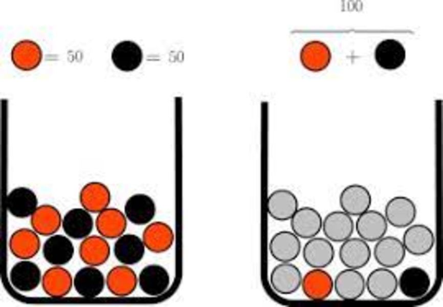

*1R*: Left Red €100

*1B*: Left Black €100

*1R*: Left Red €100

*2R*: Right Red €100

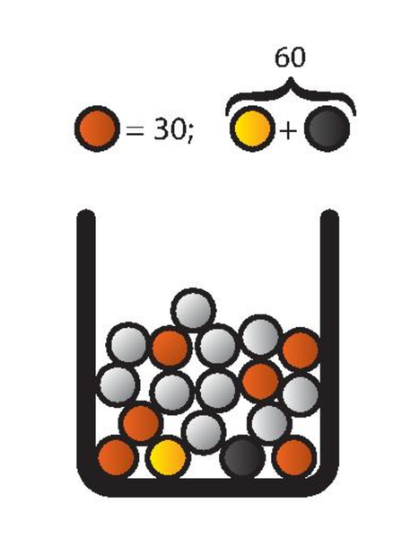

*1R*: Red €100

*2R*: Black €100

*1R*: Red and Black €100

*2R*: Black and Yellow €100

# What Do We Do?

What are we dealing with?

Quantify risks

Manage uncertainties

# Summary

Thank You

mcooney@describedata.com

https://github.com/kaybenleroll/data_workshops